# Disparities in Imprisonment Rates Among Different Ethnicities

## Introduction:

Across the United States, claims have been made that state how Law Enforcement tends to **over-police individuals of color**. One’s definition of over-policing may vary, whether it relates to how often an officer pursues a law breaker, how minor of a crime gets called out, etc.

For the purpose of this analysis, I chose to focus on the incarceration totals of different ethnicities utilizing data between the years of 1990 and 2018.

As the number of *white individuals* within different counties in the United States tended to be higher than the number of *black individuals*, averages and percentages of the totals were used so that a better comparison can be made.

In the **Midwest in 2016**, roughly one in 61 black individuals were behind bars, and roughly one in 331 white individuals were behind bars. Compared to **1990**, the ratio of black individuals behind bars was around one in 72, as compared to the ratio of white individuals behind bars which was around one in 811.

In the **Northeast in 2016**, roughly one in 70 black individuals were behind bars, and roughly one in 517 white individuals were behind bars. Compared to **1990**, the ratio of black individuals behind bars was around one in 142, as compared to the ratio of white individuals behind bars which was around one in 2074.

In the **South in 2016**, roughly one in 79 black individuals were behind bars, and roughly one in 242 white individuals were behind bars. Compared to **1990**, the ratio of black individuals behind bars was around one in 99, as compared to the ratio of white individuals behind bars which was around one in 608.

## Time Trend Chart

As the number of people imprisoned changes year by year, it helps to look at how the data changes over time to get a better perspective of the over-policing issue. Below is included a graph that looks at how the **Black Prison Population**, the **Latinx Prison Population**, and the **White Prison Population** percentages have changed between the years of 1990 and 2016.

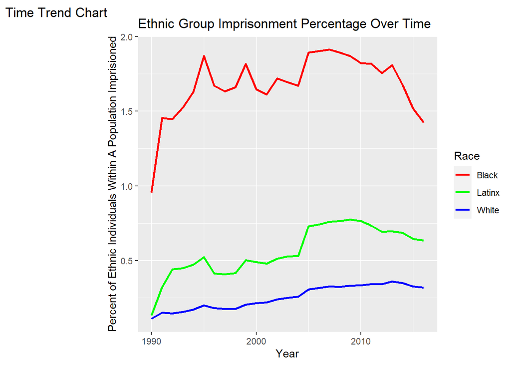

## Variable Comparison Chart

As mentioned earlier in the analysis, the ratio between the total number of individuals within ethnicity and the amount that are imprisoned is important to realize in order to get a better grasp of the issue, as even though there are a similar number of Black people and White people imprisoned, there is many more White people within the United States. Below is a graph that helps put this into perspective, with the **red bar** being the total number of individuals within said population, and the **blue bar** being the number of those individuals who are incarcerated.

(NOTE: The blue bar for both is typically much lower, however to help visualize it, the total population for both the Black and White communities has been divided by 10.)

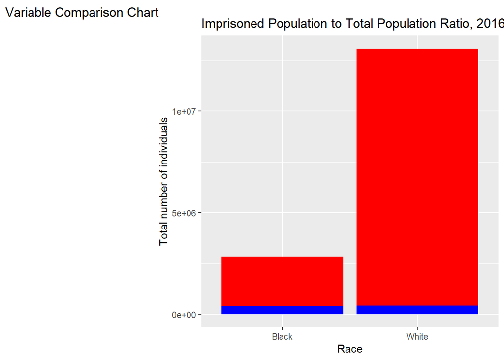

As expected, the bar for the Black and White populations could be swapped and it would be hard to tell if any change had been made, however the red bars show that the ratio between the two data points is massive.

## Map

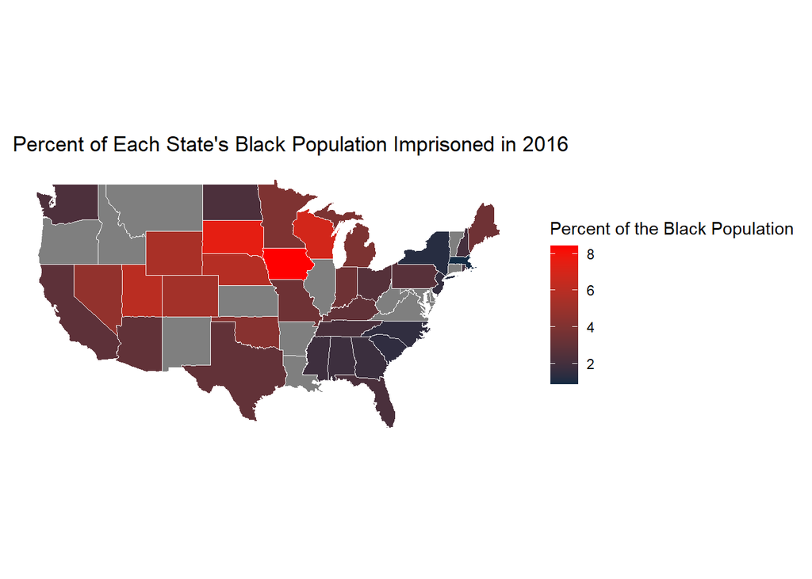

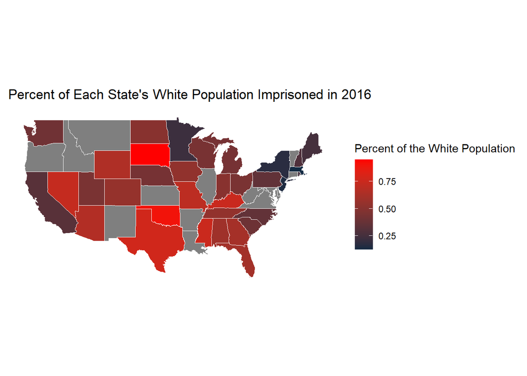

In the center of the country seems to be the point where the highest amount of police actions take place, however it takes place much more often with the black population, as the White percentage never hits 1%, and the Black data surpasses 8%.